# High School and Beyond survey Classification Problem

# Decile Lift Chart

The decile lift chart displays the lift over the global mean event rate for each decile. For a model with good discriminatory power, the top deciles should have an event/conversion rate greater than the global mean.

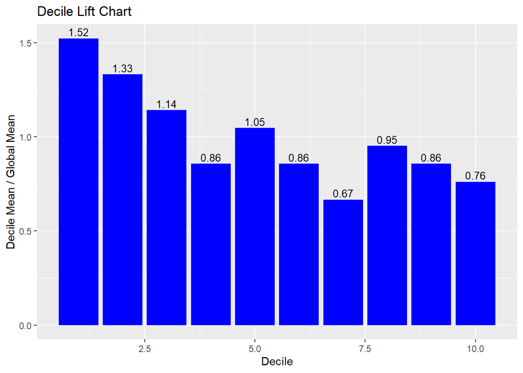

```r
q <- blr_gains_table(model)
blr_decile_lift_chart(q)
```

# Capture Rate by Decile

If the model has good discriminatory power, the top deciles should have a higher event/conversion rate compared to the bottom deciles.

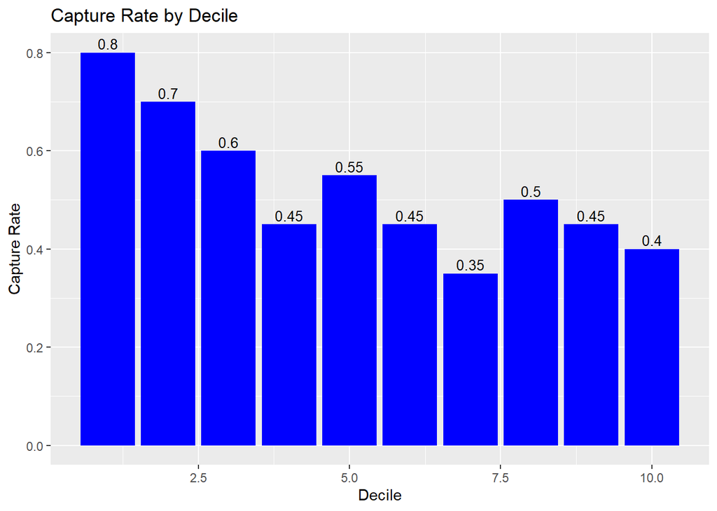

```r
b <- blr_gains_table(model)
blr_decile_capture_rate(b)
```

# Lorenz Curve

The Lorenz curve is a simple graphic device which illustrates the degree of inequality in the distribution of thevariable concerned. It is a visual representation of inequality used to measure the discriminatory power of the predictive model.

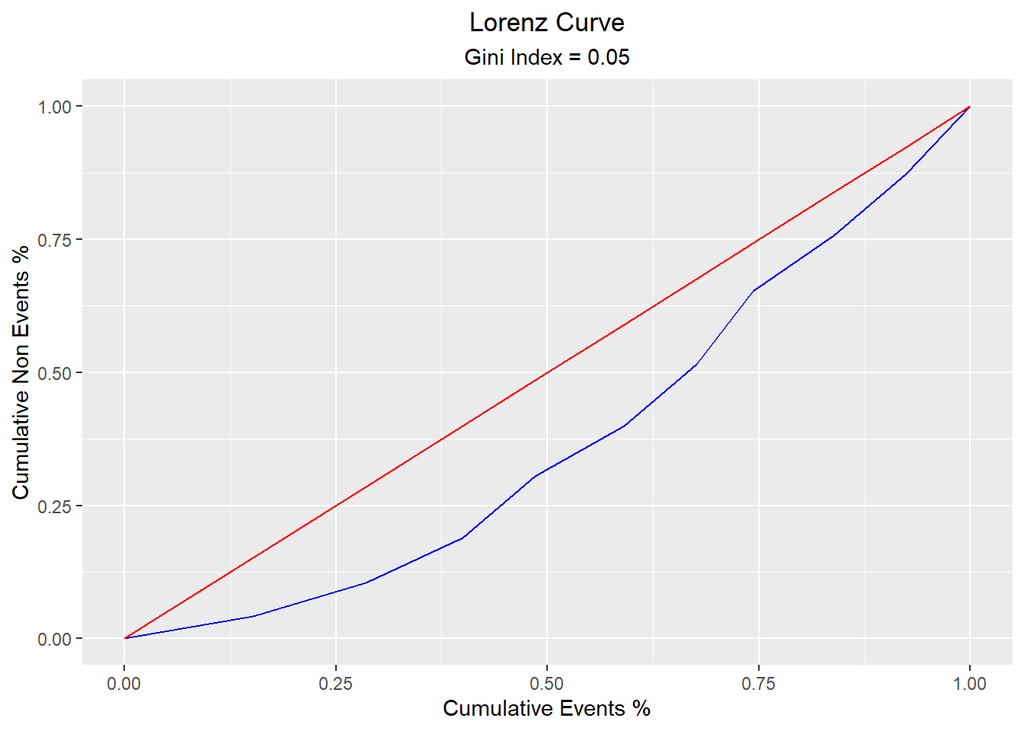

```r
blr_lorenz_curve(model)
```

# Residual & Influence Diagnostics

blorr can generate 22 plots for residual, influence and leverage diagnostics.

## Influence Diagnostics

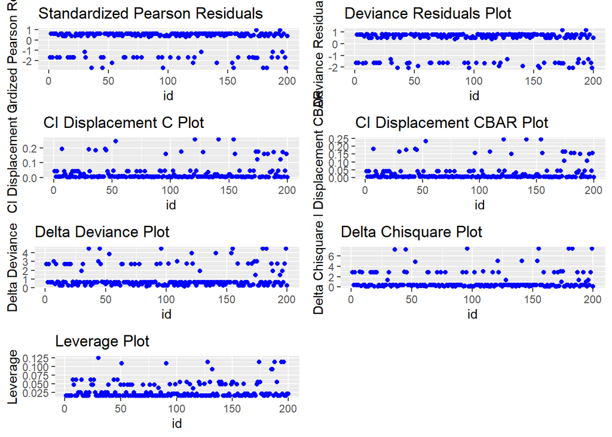

```r
blr_plot_diag_influence(model)
```

## Leverage Diagnostics

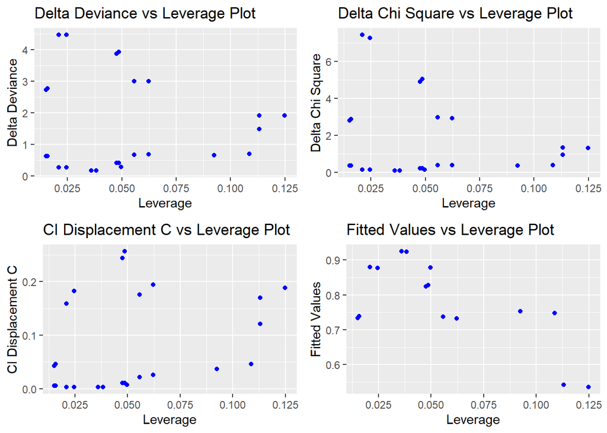

```r
blr_plot_diag_leverage(model)
```

## Fitted Values Diagnostics

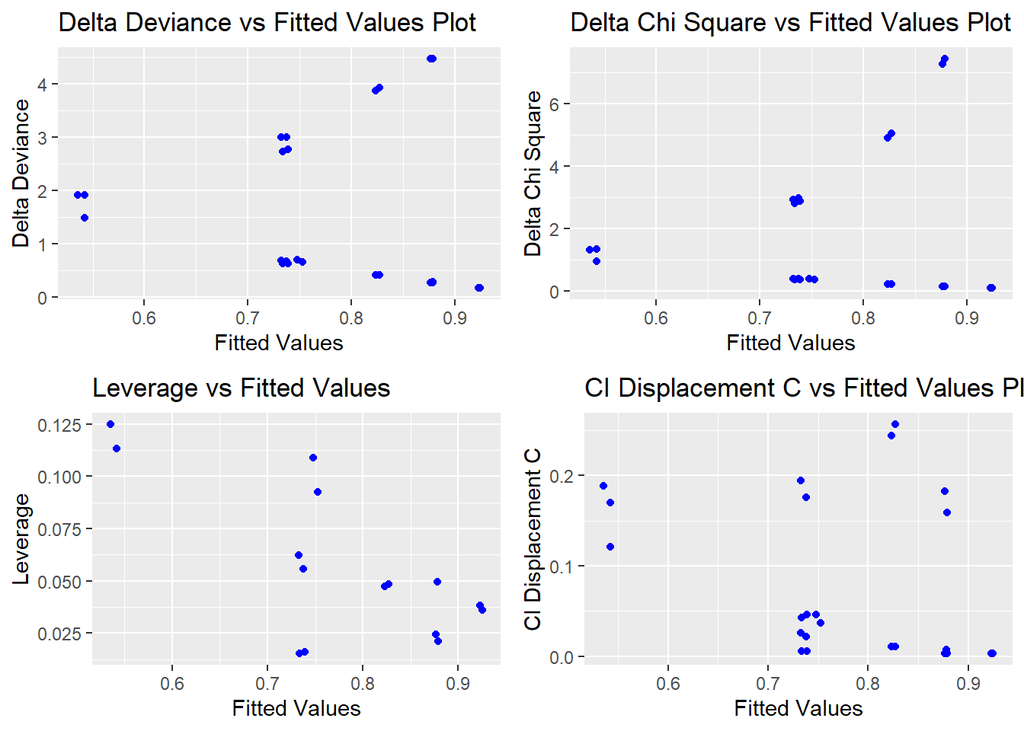

```r
blr_plot_diag_fit(model)
```

# References

A Short Introduction to the blorr Package Aravind Hebbali Source: vignettes/introduction.Rmd https://blorr.rsquaredacademy.com/articles/introduction.html